# Proyecto Dashboard Consulta al Turista

Integración al Observatorio Turístico de la Provincia del Neuquén

Ministerio de Turismo de la Provincia del Neuquén

13/07/2026

[figure not shown]

Observatorio Turístico

Dashboard Consulta al Turista

Documento técnico de integración al Observatorio Turístico

Visualización, análisis e interpretación de indicadores de demanda turística

[figure not shown]

Proyecto Dashboard Consulta al Turista Integración al Observatorio Turístico de la Provincia del Neuquén

El presente documento técnico describe el desarrollo, implementación e integración del Dashboard Consulta al Turista como una herramienta operativa del Observatorio Turístico de la Provincia del Neuquén.

El dashboard permite transformar datos provenientes de formularios digitales en información útil para la gestión turística, la planificación territorial, el seguimiento de la demanda, la comunicación institucional y la toma de decisiones basada en evidencia.

La solución desarrollada integra un flujo dinámico de información que conecta la recolección de datos mediante formularios digitales, su almacenamiento en una fuente actualizable y su visualización interactiva en un tablero web implementado en Shiny.

# 1. Fundamentación del proyecto

El turismo provincial requiere contar con información actualizada, territorializada y comprensible para orientar políticas públicas, acciones de promoción, estrategias de marketing, planificación de destinos y asistencia al sector privado.

En muchos procesos de relevamiento turístico, la información recolectada queda dispersa en planillas, formularios o registros aislados, dificultando su análisis oportuno y su utilización para la toma de decisiones.

El Dashboard Consulta al Turista responde a esta necesidad mediante una herramienta que permite visualizar en tiempo casi real los principales indicadores de las consultas realizadas por turistas y visitantes.

De esta manera, el proyecto fortalece el rol del Observatorio Turístico como espacio de producción, análisis e interpretación de información estratégica para la Provincia del Neuquén.

# 2. Objetivo general

Desarrollar e implementar un dashboard interactivo integrado al Observatorio Turístico de la Provincia del Neuquén, orientado a visualizar, analizar e interpretar datos provenientes de consultas al turista, con actualización dinámica y enfoque territorial.

# 3. Objetivos específicos

- Sistematizar la información relevada mediante formularios digitales de consulta al turista.
- Integrar los datos recolectados a una fuente dinámica de actualización continua.
- Visualizar la distribución territorial de las respuestas según regiones turísticas provinciales.
- Identificar los principales destinos consultados por los visitantes.
- Analizar la procedencia de la demanda turística relevada.
- Caracterizar el perfil del visitante según grupo de viaje, tipo de alojamiento, estadía y actividades declaradas.
- Generar indicadores sintéticos para facilitar la interpretación de los datos.
- Fortalecer la toma de decisiones en materia de planificación, promoción, gestión territorial y desarrollo turístico.
- Incorporar el dashboard como herramienta operativa dentro del Observatorio Turístico provincial.
- Registrar y organizar información proveniente de consultas realizadas **in situ** en oficinas de informes turísticos distribuidas en el territorio provincial.
- Aportar una lectura territorial de la demanda consultante, considerando el alcance y las limitaciones propias del punto de captura de datos.

## 3.1 Consideración metodológica sobre la captura del dato

La información utilizada por el Dashboard Consulta al Turista surge de datos relevados **in situ** en oficinas de informes turísticos distribuidas en distintas localidades de la Provincia del Neuquén.

Este aspecto resulta relevante para la interpretación de los resultados, ya que el universo analizado está compuesto por turistas o visitantes que efectivamente se acercan a realizar una consulta o reciben asistencia en dichos espacios de información turística.

Por lo tanto, los datos deben interpretarse como una caracterización de la **demanda consultante registrada en oficinas de informes**, y no como una medición exhaustiva de la totalidad de turistas que visitan la provincia.

Esta condición puede introducir sesgos propios del punto de captura, dado que ciertos perfiles de visitantes pueden estar más representados que otros. Por ejemplo, pueden tener mayor presencia quienes requieren orientación presencial, quienes visitan destinos con oficinas activas, quienes acceden a circuitos de información institucional o quienes se encuentran en localidades con mayor capacidad de relevamiento.

En consecuencia, los indicadores generados por el dashboard deben ser interpretados como insumos estratégicos para observar tendencias, perfiles, procedencias, intereses y comportamientos de la demanda consultante, complementando otros sistemas de información turística disponibles en el Observatorio.

# 4. Necesidad institucional a la que da respuesta

El dashboard da respuesta a la necesidad de contar con una herramienta institucional que permita pasar de la simple recolección de datos a la generación de información útil para la toma de decisiones.

La herramienta permite responder preguntas estratégicas como:

¿Desde dónde provienen los turistas consultados? ¿Qué regiones turísticas concentran mayor participación en las consultas? ¿Qué destinos aparecen con mayor frecuencia? ¿Cómo se compone el grupo de viaje? ¿Qué tipo de alojamiento utilizan o declaran los visitantes? ¿Cuál es la estadía promedio declarada? ¿Qué actividades o intereses turísticos predominan? ¿Cómo se distribuyen territorialmente las respuestas? ¿Qué información puede orientar acciones de planificación, promoción y asistencia al sector?

# 5. Integración al Observatorio Turístico

La integración del dashboard al Observatorio Turístico permite consolidar una herramienta de consulta, monitoreo y visualización de información turística en un entorno accesible para usuarios institucionales.

## Vista general de la herramienta integrada

La siguiente imagen presenta una vista general del Dashboard Consulta al Turista, donde se observa la estructura principal de la herramienta: encabezado institucional, indicadores superiores, filtros interactivos, mapa regionalizado, resumen ejecutivo y componentes gráficos.

[figure not shown]

Vista general del Dashboard Consulta al Turista integrado al Observatorio Turístico.

El esquema de integración contempla el siguiente flujo:

El turista completa un formulario digital de consulta. Las respuestas se almacenan automáticamente en una hoja de cálculo dinámica. El dashboard procesa y normaliza la información relevante. Los datos se visualizan mediante indicadores, filtros, gráficos y mapa regional. El Observatorio Turístico incorpora el dashboard como herramienta de análisis e interpretación para la gestión.

Esta integración permite que el Observatorio no funcione únicamente como un repositorio de información, sino como una plataforma activa de inteligencia turística.

# 6. Valor institucional del dashboard

El Dashboard Consulta al Turista aporta valor institucional porque permite:

Mejorar la disponibilidad de información actualizada. Reducir tiempos entre la recolección y el análisis de datos. Facilitar la lectura territorial de la demanda turística. Apoyar decisiones de planificación y promoción. Fortalecer el rol del Observatorio Turístico como sistema de inteligencia. Generar evidencia para orientar políticas públicas. Mejorar la comunicación de resultados mediante visualizaciones claras. Promover una cultura de gestión basada en datos.

# 7. Alcance inicial del proyecto

En esta primera etapa, el dashboard se orienta al análisis de consultas al turista a partir de los siguientes componentes:

Cantidad total de encuestas registradas. Cantidad estimada de personas representadas. Estadía promedio declarada. Cantidad de destinos identificados. Distribución por regiones turísticas. Principales procedencias. Grupo de viaje predominante. Tipo de alojamiento declarado. Actividades o intereses turísticos principales. Tabla resumen territorial para consulta interna.

# 8. Síntesis

El Dashboard Consulta al Turista constituye una herramienta estratégica para transformar datos de consulta en información útil para la gestión turística provincial.

Su integración al Observatorio Turístico fortalece la capacidad institucional de observar, interpretar y actuar sobre la dinámica de la demanda turística, aportando evidencia para la planificación territorial, el diseño de políticas públicas, la comunicación turística y la toma de decisiones basada en datos.

# 9. Interpretación de indicadores del dashboard

El dashboard presenta un conjunto de indicadores clave de desempeño, o KPIs, orientados a facilitar la lectura rápida del comportamiento de la demanda turística relevada mediante la consulta al turista.

Estos indicadores permiten transformar las respuestas individuales del formulario en información sintética, territorializada y útil para la toma de decisiones.

## Visualización de indicadores principales

Los indicadores superiores permiten una lectura rápida del estado general del relevamiento. Estos KPIs resumen el volumen de encuestas, personas representadas, estadía promedio, destinos identificados, regiones, alojamientos y actividades declaradas.

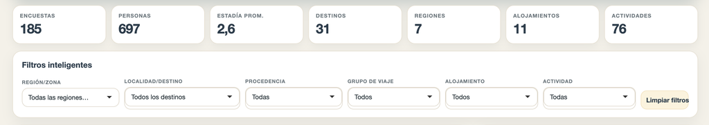

Indicadores principales del Dashboard Consulta al Turista.

## 9.1 Encuestas

El indicador **Encuestas** representa la cantidad total de respuestas válidas registradas en el sistema.

Este dato permite conocer el volumen de información disponible para el análisis. A mayor cantidad de encuestas, mayor robustez tendrá la lectura general de los resultados.

Su interpretación debe considerar que se trata de respuestas relevadas mediante consulta directa, por lo que representa el universo efectivamente registrado en el formulario y no necesariamente la totalidad de turistas presentes en el territorio.

## 9.2 Personas

El indicador **Personas** estima la cantidad total de visitantes representados por las encuestas, considerando la cantidad de integrantes declarados en cada grupo de viaje.

Este dato permite ampliar la lectura del relevamiento, ya que una encuesta puede representar a una persona individual o a un grupo familiar, de amigos o acompañantes.

Su utilidad principal es dimensionar el alcance aproximado de las consultas realizadas y estimar el volumen de personas asociadas a las respuestas registradas.

## 9.3 Estadía promedio

El indicador **Estadía promedio** expresa la cantidad promedio de noches declaradas por los visitantes.

Este dato resulta relevante para interpretar el nivel de permanencia en el destino o región. Una estadía más prolongada puede asociarse a mayor uso de servicios turísticos, mayor consumo local y mayor impacto económico potencial.

En el dashboard, las respuestas de estadía se transforman en valores numéricos para poder calcular un promedio aproximado.

## 9.4 Destinos

El indicador **Destinos** muestra la cantidad de localidades o destinos turísticos identificados en las respuestas.

Permite observar la diversidad territorial de las consultas y conocer cuántos destinos forman parte del universo relevado.

Este indicador es útil para evaluar la amplitud territorial de la demanda y detectar destinos con mayor o menor presencia en las consultas.

## 9.5 Regiones

El indicador **Regiones** representa la cantidad de regiones turísticas provinciales contempladas en el análisis.

La regionalización permite ordenar la información territorialmente y facilitar una lectura estratégica a escala provincial.

En este proyecto se trabaja sobre las regiones turísticas de la Provincia del Neuquén, permitiendo agrupar destinos y localidades según criterios territoriales e institucionales.

## 9.6 Participación regional

## Visualización territorial de la participación regional

El mapa regionalizado permite observar la distribución porcentual de las consultas según las regiones turísticas de la Provincia del Neuquén. Esta visualización facilita una lectura territorial inmediata del relevamiento.

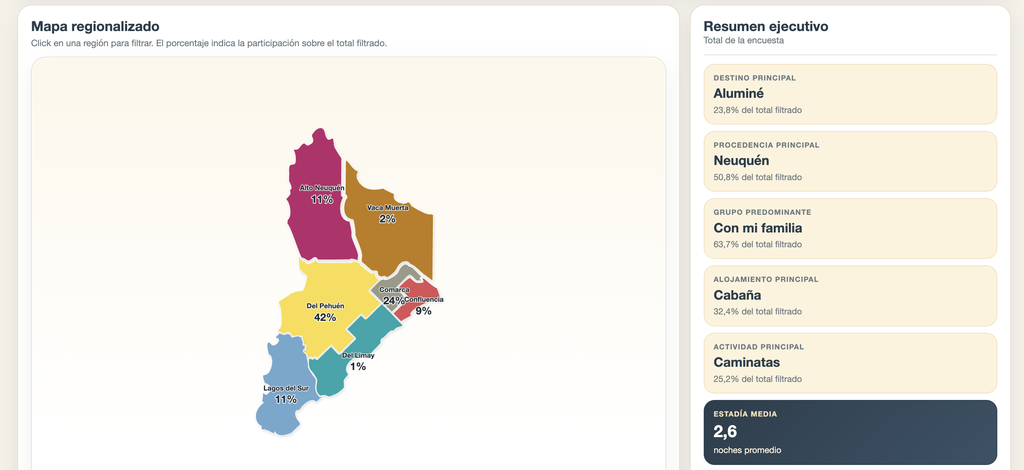

Mapa regionalizado con participación porcentual por región turística.

La **participación regional** indica qué porcentaje representa cada región turística sobre el total de encuestas válidas con región identificada.

Este indicador se visualiza en el mapa regionalizado del dashboard y permite interpretar la distribución territorial de las consultas.

## 9.7 Destino principal

El indicador Destino principal muestra el destino o localidad con mayor frecuencia dentro del universo filtrado.

Si no se aplica ningún filtro, representa el destino más mencionado en el total de la encuesta. Si se aplica un filtro por región, procedencia, alojamiento o actividad, el indicador se recalcula sobre ese subconjunto de datos.

Este KPI permite identificar rápidamente el destino de mayor peso dentro de la selección analizada.

## 9.8 Procedencia principal

El indicador Procedencia principal identifica el lugar de residencia más frecuente de los visitantes consultados.

Este dato es clave para reconocer los principales mercados emisores y orientar estrategias de promoción, comunicación y segmentación de públicos.

También permite analizar si determinadas regiones o destinos reciben mayor proporción de visitantes locales, provinciales, nacionales o internacionales.

## 9.9 Grupo predominante

El indicador Grupo predominante describe la forma de composición del viaje más frecuente entre los visitantes relevados.

Puede incluir categorías como familia, pareja, amigos, viaje individual u otras formas de acompañamiento.

Este dato es útil para adaptar propuestas turísticas, mensajes promocionales, servicios y experiencias según el perfil del grupo visitante.

## 9.10 Alojamiento principal

El indicador Alojamiento principal muestra el tipo de alojamiento más declarado por los visitantes consultados.

Permite identificar patrones de uso de servicios turísticos y comprender mejor la modalidad de permanencia en el destino.

Este indicador puede aportar información relevante para el sector privado, áreas de fiscalización, planificación de infraestructura y diseño de políticas de alojamiento turístico.

## 9.11 Actividad principal

## Resumen ejecutivo del universo filtrado

El panel de resumen ejecutivo permite interpretar rápidamente los principales atributos del conjunto de datos seleccionado. Al aplicar filtros, el sistema actualiza automáticamente el destino principal, procedencia principal, grupo predominante, alojamiento principal, actividad principal y estadía media.

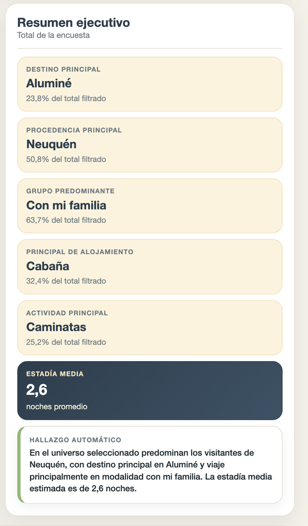

Panel de resumen ejecutivo del dashboard.

El indicador Actividad principal identifica la actividad o interés turístico más mencionado en las respuestas.

Este dato permite reconocer motivaciones de viaje, preferencias de los visitantes y oportunidades para el desarrollo de productos turísticos.

Su interpretación es especialmente relevante para áreas de promoción, diseño de experiencias, planificación territorial y diversificación de la oferta.

# 10. Lectura de filtros del sistema

## Filtros interactivos del sistema

Los filtros permiten segmentar la información y generar lecturas específicas según las necesidades del usuario. Cada selección modifica automáticamente los indicadores, gráficos, mapa y resumen ejecutivo.

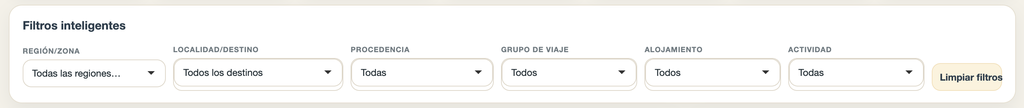

Filtros interactivos del Dashboard Consulta al Turista.

El dashboard incorpora filtros interactivos que permiten analizar la información por distintos criterios.

Los principales filtros son:

Región turística. Localidad o destino. Procedencia. Grupo de viaje. Tipo de alojamiento. Actividad declarada.

Cada vez que el usuario aplica un filtro, los indicadores, gráficos, mapa y resumen ejecutivo se actualizan automáticamente.

Esto permite realizar lecturas específicas, por ejemplo:

Perfil de visitantes de una región determinada. Procedencia principal de quienes visitan un destino. Tipo de alojamiento predominante en una localidad. Actividades más consultadas por un mercado emisor. Composición del grupo de viaje según región o destino.

De esta manera, el dashboard no solo muestra datos generales, sino que permite explorar la información de forma dinámica según las necesidades del usuario del sistema.

# 11. Utilidad para la gestión turística

## Visualizaciones analíticas complementarias

Los gráficos inferiores complementan la lectura de los KPIs al mostrar distribuciones y rankings de las principales variables del relevamiento. Estas visualizaciones permiten identificar patrones de demanda y comparar categorías de manera rápida.

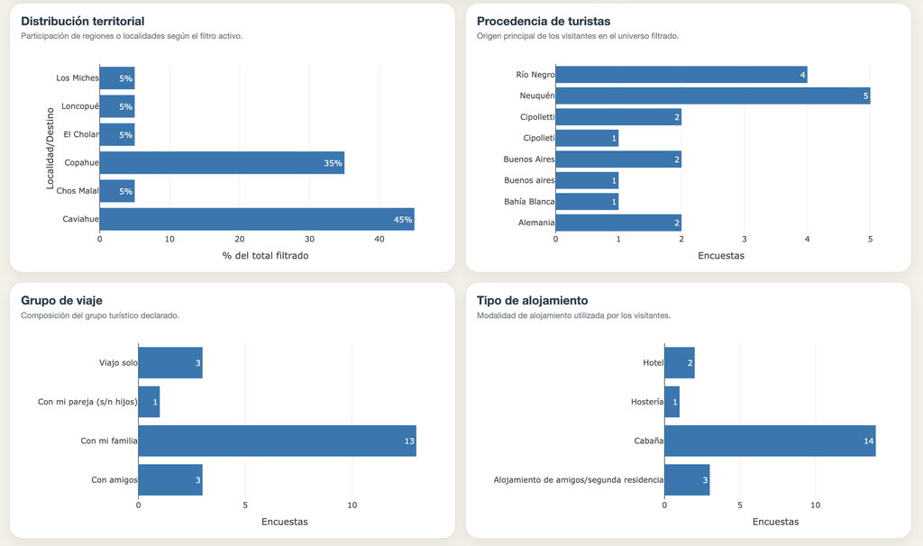

Gráficos analíticos inferiores del dashboard.

La interpretación de los indicadores permite generar insumos concretos para distintas áreas de trabajo.

## 11.1 Planificación territorial

El dashboard permite observar cómo se distribuyen las consultas entre regiones y destinos, aportando información para priorizar acciones territoriales, identificar áreas de mayor demanda y detectar regiones con menor representación en los relevamientos.

## 11.2 Marketing y promoción

Los datos de procedencia, actividades principales y destinos consultados permiten orientar campañas de comunicación hacia mercados específicos y diseñar mensajes acordes al perfil de los visitantes.

## 11.3 Desarrollo de productos turísticos

La información sobre actividades, estadía, grupo de viaje y alojamiento permite identificar oportunidades para fortalecer productos existentes o desarrollar nuevas propuestas adaptadas a la demanda.

## 11.4 Gestión institucional

La disponibilidad de indicadores actualizados facilita el seguimiento de la demanda, la elaboración de reportes, la comunicación de resultados y la toma de decisiones basada en evidencia.

## 11.5 Observatorio Turístico

La integración del dashboard al Observatorio fortalece su rol como plataforma activa de inteligencia turística, permitiendo pasar de la simple publicación de información a la generación de conocimiento aplicable a la gestión pública.

# 12. Arquitectura funcional del sistema

El Dashboard Consulta al Turista se estructura como un sistema integrado de captura, procesamiento, visualización y publicación de información turística.

La arquitectura funcional combina herramientas de relevamiento digital, almacenamiento dinámico de datos, procesamiento en lenguaje R, visualización interactiva mediante Shiny y publicación web para su integración al Observatorio Turístico.

El sistema se compone de los siguientes elementos principales:

## 12.1 Formulario digital de consulta

El primer componente del sistema es el formulario digital utilizado para relevar información de turistas y visitantes.

Este formulario permite capturar respuestas estructuradas sobre variables clave como destino visitado, región turística, procedencia, grupo de viaje, estadía, alojamiento, actividades e intereses turísticos.

La utilización de formularios digitales permite reducir errores de carga, agilizar el relevamiento y ordenar la información desde el momento de la captura.

## 12.2 Hoja de cálculo dinámica

Las respuestas del formulario se almacenan automáticamente en una hoja de cálculo vinculada.

Esta hoja funciona como base de datos operativa del sistema, permitiendo que cada nueva respuesta quede registrada y disponible para su procesamiento.

En esta etapa se incorporan columnas de normalización, como la asignación de región turística, permitiendo que el dashboard pueda interpretar territorialmente cada respuesta.

## 12.3 Procesamiento en R

El dashboard fue desarrollado en lenguaje R, utilizando Shiny como framework principal para la construcción de la aplicación web interactiva.

El procesamiento incluye tareas de lectura de datos, limpieza básica, normalización de campos, cálculo de indicadores, generación de filtros, construcción de gráficos y actualización del mapa regionalizado.

Este procesamiento permite transformar datos crudos provenientes del formulario en información organizada y visualmente interpretable.

## 12.4 Aplicación Shiny

La aplicación Shiny constituye la interfaz principal del sistema.

A través de ella, el usuario puede consultar indicadores, aplicar filtros, visualizar gráficos, explorar el mapa regionalizado y acceder a una tabla resumen territorial.

La interfaz fue diseñada para facilitar una lectura ejecutiva y operativa de los datos, priorizando claridad visual, navegación simple e interpretación rápida de los resultados.

## 12.5 Publicación en shinyapps.io

La aplicación fue publicada en shinyapps.io, lo que permite acceder al dashboard mediante un enlace web.

Esta publicación permite que el sistema pueda ser consultado desde un navegador, sin necesidad de ejecutar RStudio ni acceder al código fuente.

Cada modificación del código, diseño o estructura del dashboard requiere una nueva publicación de la aplicación. En cambio, las nuevas respuestas registradas en la hoja de cálculo pueden ser leídas dinámicamente por el sistema, según el intervalo de actualización configurado.

## 12.6 Integración al Observatorio Turístico

El dashboard puede integrarse al Observatorio Turístico mediante un enlace directo o mediante su incorporación en una página web institucional a través de un iframe.

De esta forma, el Observatorio incorpora una herramienta viva de visualización y análisis, conectada a una fuente de datos dinámica y orientada a la toma de decisiones.

# 13. Flujo de información del sistema

El funcionamiento del sistema puede resumirse en el siguiente flujo:

1. El turista o visitante completa el formulario digital.
2. La respuesta queda almacenada automáticamente en la hoja de cálculo vinculada.
3. La hoja incorpora o conserva variables clave para el análisis, incluyendo la región turística.
4. La aplicación Shiny lee la fuente de datos dinámica.
5. El sistema procesa, limpia y organiza la información.
6. El dashboard actualiza indicadores, gráficos, mapa y tabla resumen.
7. El usuario institucional interpreta la información desde el Observatorio Turístico.

Este flujo permite reducir la distancia entre el relevamiento de datos y su uso efectivo para la gestión turística.

# 14. Criterios de procesamiento de datos

## Tabla resumen territorial

La tabla resumen territorial permite consultar de manera estructurada los principales indicadores por región, facilitando una lectura comparativa y técnica de los datos procesados.

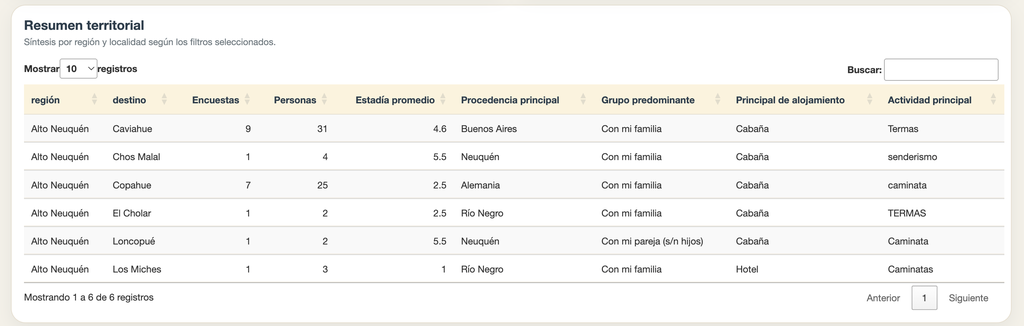

Tabla resumen territorial del dashboard.

Para que los datos puedan ser visualizados e interpretados correctamente, el dashboard aplica criterios de procesamiento y normalización.

Entre los principales criterios se incluyen:

- Lectura de datos desde una fuente dinámica.
- Identificación de respuestas válidas.
- Normalización de nombres de regiones turísticas.
- Limpieza de campos de texto.
- Conversión de categorías de estadía a valores numéricos aproximados.
- Cálculo de cantidad estimada de personas representadas.
- Identificación de valores predominantes mediante frecuencia.
- Cálculo de participación porcentual por región.
- Actualización de gráficos e indicadores según filtros seleccionados.

Estos criterios permiten transformar respuestas individuales en indicadores comparables y útiles para el análisis.

# 15. Actualización dinámica de la información

El dashboard fue diseñado para trabajar con una fuente de datos dinámica.

Esto significa que, a medida que se incorporan nuevas respuestas al formulario, la hoja de cálculo se actualiza automáticamente y el dashboard puede leer esos nuevos registros según el intervalo de actualización definido en la aplicación.

La actualización dinámica permite disponer de información más cercana al tiempo real, reduciendo la necesidad de descargar, consolidar y procesar manualmente las respuestas.

Es importante diferenciar dos tipos de actualización:

## 15.1 Actualización de datos

La actualización de datos se produce cuando ingresan nuevas respuestas al formulario o se modifica la hoja de cálculo fuente.

Este tipo de actualización puede reflejarse en el dashboard sin modificar el código, siempre que la aplicación publicada continúe leyendo correctamente la fuente de datos.

## 15.2 Actualización del sistema

La actualización del sistema ocurre cuando se modifican elementos del código, diseño, estructura, filtros, gráficos, mapa o lógica de cálculo.

En este caso, es necesario volver a publicar la aplicación en shinyapps.io para que los cambios impacten en la versión online.

# 16. Integración web mediante iframe

Una de las formas de incorporar el dashboard al Observatorio Turístico es mediante un iframe dentro de una página institucional.

Este mecanismo permite mostrar la aplicación Shiny dentro de una sección del sitio web, manteniendo la interacción del usuario con filtros, mapa, gráficos e indicadores.

Un ejemplo de integración web sería:

```html
<iframe
  src="https://usuario.shinyapps.io/nombre_app/"
  style="border: none; width: 100%; height: 950px;"
  frameborder="0">
</iframe>
```

La altura del iframe puede ajustarse según el diseño del sitio web y la cantidad de contenido visible del dashboard.

# 17. Roles de usuario del sistema

El dashboard puede ser utilizado por distintos perfiles institucionales.

## 17.1 Usuario de gestión

Puede utilizar el sistema para interpretar rápidamente el comportamiento general de la demanda relevada, identificar regiones con mayor participación y observar indicadores sintéticos para la toma de decisiones.

## 17.2 Usuario técnico

Puede analizar filtros específicos, revisar distribuciones territoriales, explorar gráficos y detectar patrones en los datos.

## 17.3 Usuario de planificación

Puede utilizar la información para orientar acciones territoriales, identificar destinos con mayor presencia en las consultas y reconocer áreas que requieren mayor seguimiento.

## 17.4 Usuario de marketing y comunicación

Puede interpretar mercados emisores, procedencias principales, actividades de interés y perfiles de viaje para orientar campañas, mensajes y estrategias de promoción.

## 17.5 Usuario del Observatorio Turístico

Puede incorporar el dashboard como herramienta de monitoreo, análisis y comunicación de información estratégica, fortaleciendo el sistema provincial de inteligencia turística.

# 18. Consideraciones para la implementación

Para asegurar el correcto funcionamiento del dashboard en etapa de implementación, se recomienda considerar los siguientes aspectos:

- Mantener activa y accesible la hoja de cálculo fuente.
- Verificar periódicamente que las columnas del formulario no cambien de nombre.
- Controlar que la asignación de regiones turísticas se mantenga actualizada.
- Evitar modificar la estructura del formulario sin revisar el impacto en el dashboard.
- Realizar copias de seguridad antes de modificar el código de la aplicación.
- Probar localmente cada cambio antes de volver a publicar en shinyapps.io.
- Documentar los cambios realizados en cada nueva versión.
- Controlar el consumo de horas y recursos disponibles en la cuenta de shinyapps.io.
- Validar que la integración web funcione correctamente en navegadores externos.

# 19. Escalabilidad del proyecto

El Dashboard Consulta al Turista fue desarrollado como una primera etapa funcional, pero su estructura permite futuras ampliaciones.

Entre las posibles líneas de evolución se encuentran:

- Incorporación de nuevos formularios de relevamiento.
- Comparación entre temporadas.
- Incorporación de series históricas.
- Integración de datos de ocupación hotelera.
- Cruce con información de procedencia de la demanda.
- Visualización por productos turísticos.
- Incorporación de indicadores económicos.
- Desarrollo de reportes automáticos.
- Integración con otras fuentes del Observatorio Turístico.
- Implementación de usuarios diferenciados para acceso interno y público.

La escalabilidad del sistema permite proyectar al dashboard como una herramienta adaptable a distintas necesidades del Observatorio y del Ministerio de Turismo.

# 20. Conclusión técnica

La implementación del Dashboard Consulta al Turista representa un avance en la consolidación de herramientas digitales para la gestión inteligente de la información turística.

El sistema permite integrar relevamiento, procesamiento, visualización y publicación en un flujo operativo único, facilitando el acceso a información actualizada y territorializada.

Su incorporación al Observatorio Turístico fortalece la capacidad institucional de monitorear la demanda, interpretar comportamientos, generar evidencia y acompañar la toma de decisiones estratégicas para el desarrollo turístico provincial.

[⏻ Ingresar al Dashboard](https://gvalenzuela.shinyapps.io/dashboard_consulta_turista_v5/)